# Scatterplot Matrices

```python
import pandas as pd
from pandas.plotting import scatter_matrix
import matplotlib.pyplot as plt
import seaborn as sns
import numpy as np
from collections import Counter

sns.set(style="ticks") # use ticks on plot axes

#Switch to Jupyter Notebook mode of matplotlib (pandas is using matplotlib for the scatterplot matrix)
%matplotlib inline
```

```python
df = pd.read_csv('./soccer.csv')  # Load the dataset
```

```python
# Inspect the dataset
# See https://pandas.pydata.org/pandas-docs/stable/reference/frame.html
df.dtypes # No semicolon to see the output in the notebook
```

```
player             object
age                 int64
current_club       object
current_league     object
foot               object
height              int64
nationality        object
position           object
games12           float64
games13           float64
games14           float64
games15           float64
games16           float64
games17           float64
goals12           float64
goals13           float64
goals14           float64
goals15           float64
goals16           float64
goals17           float64
minutes12         float64
minutes13         float64
minutes14         float64
minutes15         float64
minutes16         float64
minutes17         float64
assists12         float64
assists13         float64
assists14         float64
assists15         float64
assists16         float64
assists17         float64
dtype: object
```

```python
# Take a glimpse into the data
df.head() # No semicolon to see the output in the notebook
```

|  | player | age | current_club | current_league | foot | height | nationality | position | games12 | games13 | ... | minutes14 | minutes15 | minutes16 | minutes17 | assists12 | assists13 | assists14 | assists15 | assists16 | assists17 |
| --- | --- | --- | --- | --- | --- | --- | --- | --- | --- | --- | --- | --- | --- | --- | --- | --- | --- | --- | --- | --- | --- |
| 0 | Dmitri Poloz | 26 | Zenit St. Petersburg | RUS - Premier Liga | right | 183 | Russia | W | 22.0 | 30.0 | ... | 1522.0 | 2132.0 | 2987.0 | 1194.0 | 1.0 | 4.0 | 2.0 | 6.0 | 8.0 | 7.0 |
| 1 | Emiliano Rigoni | 25 | Zenit St. Petersburg | RUS - Premier Liga | both | 180 | Argentina Italy | W | NaN | 26.0 | ... | 2832.0 | 1533.0 | 2427.0 | 1433.0 | NaN | 0.0 | 6.0 | 6.0 | 2.0 | 3.0 |
| 2 | Sebastián Driussi | 22 | Zenit St. Petersburg | RUS - Premier Liga | both | 179 | Argentina Italy | CF | NaN | 7.0 | ... | 2231.0 | 914.0 | 2517.0 | 1571.0 | NaN | 0.0 | 4.0 | 1.0 | 3.0 | 4.0 |
| 3 | Aleksandr Kokorin | 26 | Zenit St. Petersburg | RUS - Premier Liga | right | 183 | Russia | CF | 26.0 | 23.0 | ... | 2785.0 | 1424.0 | 2889.0 | 2911.0 | 5.0 | 9.0 | 7.0 | 3.0 | 7.0 | 4.0 |
| 4 | Anton Zabolotnyi | 26 | Zenit St. Petersburg | RUS - Premier Liga | right | 188 | Russia | CF | 5.0 | 26.0 | ... | NaN | 1500.0 | 2562.0 | 2019.0 | 0.0 | 1.0 | NaN | 3.0 | 5.0 | 2.0 |

5 rows × 32 columns

```python
df.dropna().foot.unique(), Counter(df['position'])
```

```
(array(['right', 'both', 'left'], dtype=object),
 Counter({'W': 607, 'CF': 570}))
```

Hint: Pandas offers [dropna](https://pandas.pydata.org/pandas-docs/stable/reference/api/pandas.DataFrame.dropna.html) function to filter out missing data.

## Task

### Simple Scatterplot Matrix

Select a couple of numerical attributes (e.g., those of 2017) and create a scatterplot matrix (e.g., with [pandas](https://pandas.pydata.org/pandas-docs/stable/reference/api/pandas.plotting.scatter_matrix.html) or [seaborn](https://seaborn.pydata.org/generated/seaborn.pairplot.html#seaborn.pairplot)).

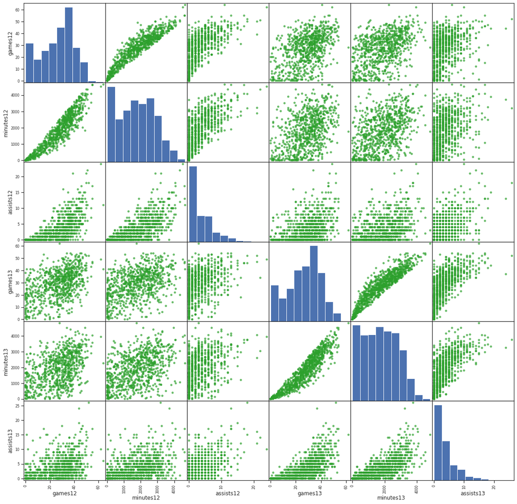

```python
pd.plotting.scatter_matrix(df[['games12','minutes12','assists12', 'games13','minutes13','assists13']],
                           figsize=(20,20),
                           alpha=0.7,
                           color='tab:green',
                           s=100
                          );
```

### Colored Scatterplot Matrix

Select a categorical attribute and encode its values with color in the scatterplot matrix. See: [seaborn pairplot](https://seaborn.pydata.org/generated/seaborn.pairplot.html#seaborn.pairplot).

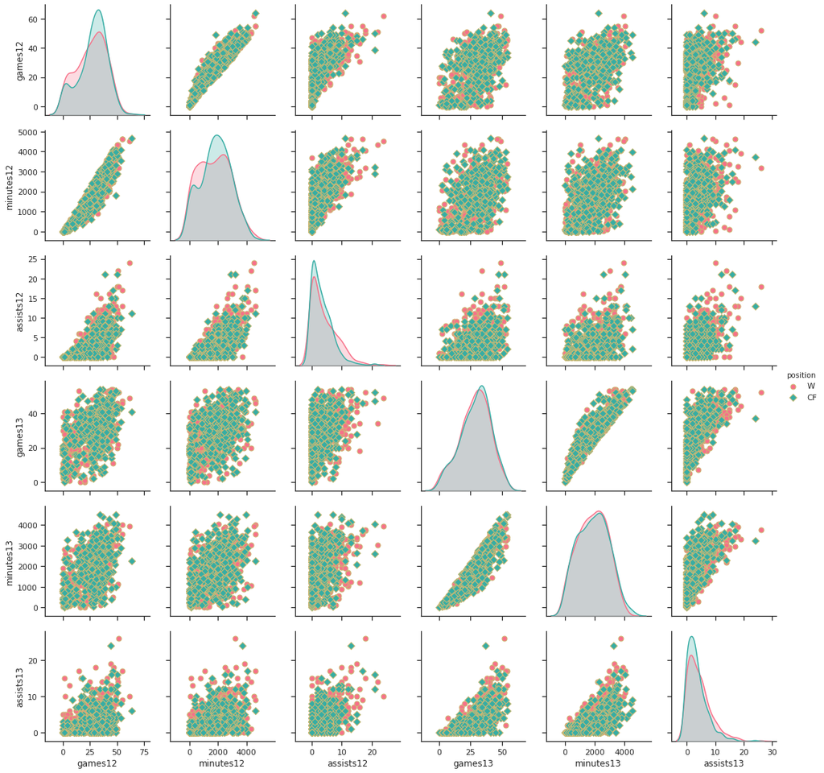

```python
g = sns.pairplot(df.dropna(),
                 vars = ['games12','minutes12','assists12', 'games13','minutes13','assists13'],
                 hue="position",
                 palette="husl",
                 markers=["o", "D"],
                 plot_kws=dict(s=50, edgecolor="y", linewidth=1),
                 )
```

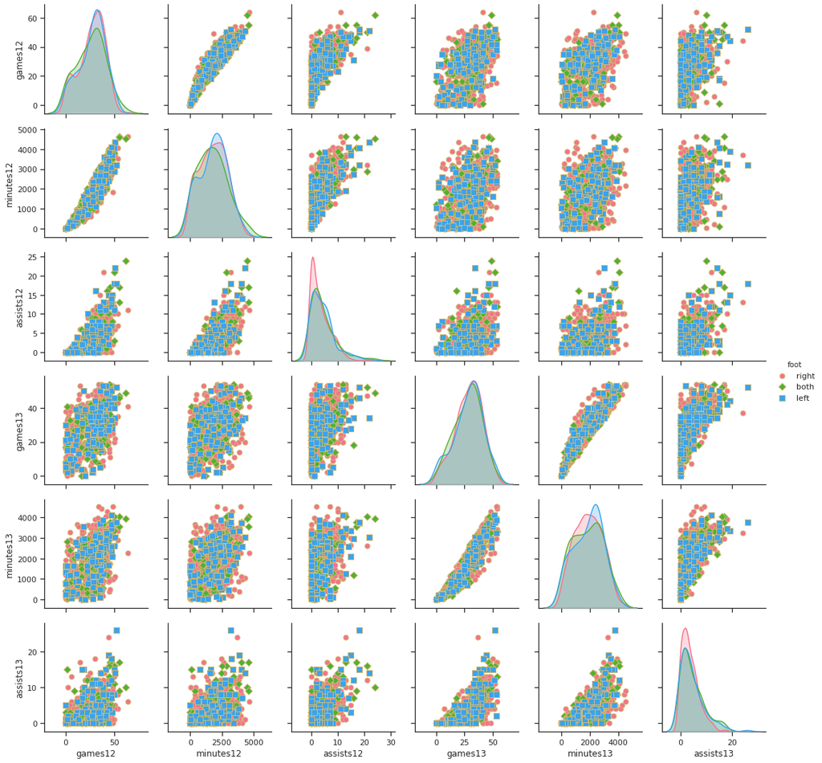

```python
g = sns.pairplot(df.dropna(),
                 vars = ['games12','minutes12','assists12', 'games13','minutes13','assists13'],
                 hue="foot",
                 palette="husl",
                 markers=["o", "D",'s'],
                 plot_kws=dict(s=50, edgecolor="y", linewidth=1))
```

### Interpretation

Scatterplot matrix generally shows relation ships between all attributes selected and also spread of all attributes as well.

We have selected attributes `['games12','minutes12','assists12', 'games13','minutes13','assists13']` to see the relationship between attributes. Diaginal generally shows spread of that attribute. Each other cell shows relationship between those two attributes who intersect there.

We can see from graphs that columns having games data and playtime has linear relationship which shows that one attribute increases with value of another attribute. Notice cell where `games12 and minutes12` & `games13 and minutes13` intersect.

We can notice that there is not particular relationship between 2 games. We can notice somewhat linear relationship between games and assists data though but its not as strong as between games and minutes.

We also have color coded based on categorical variable `position` in one graph and `foot` in another graph to differentiate points but it seems they are kind of overlaping.

## Submission

Please download this notebook as HTML (File > Download As... > HTML (.html)) and submit it.